# Austin Waste EDA

Tom Constant

14/03/2022

## Get Data

Load function to access Austin API. Function queries the Austin data API returning a `austin_api` object with tabulated data.

```r
source("austin-api.R")
```

## Get Waste Data

Save data from API if no file exists.

```r
data_file <- here::here("data", "waste.rds")

if(!file.exists(data_file)){
  api_waste <- austin_api(query = list(`$limit` = "1000000"))
  write_rds(api_waste, data_file)
}

api_waste <- read_rds(data_file)
df_waste <- api_waste$content
```

## Parse Dates

```r
df_waste <-
  df_waste %>%
  mutate(across(contains(c("time", "date")), ymd_hms))
```

## Duplicates

Check for duplicate rows.

```r
df_waste %>% summarise(n(), n_distinct())
```

```
## # A tibble: 1 x 2
##    `n()` `n_distinct()`
##    <int>          <int>
## 1 740873              0
```

## Missing Values

Find missing values.

```r
colSums(is.na(df_waste))
```

```
##  report_date    load_type    load_time  load_weight dropoff_site   route_type
##            0            0            0        72335            0            0
## route_number      load_id
##            0            0
```

```r
df_waste %>%
  filter(is.na(load_weight))
```

```
## # A tibble: 72,335 x 8
##    report_date         load_type load_time           load_weight dropoff_site
##    <dttm>              <chr>     <dttm>              <chr>       <chr>
##  1 2020-12-05 00:00:00 SWEEPING  2020-12-05 00:00:00 <NA>        ONION CREEK
##  2 2020-12-05 00:00:00 SWEEPING  2020-12-05 00:00:00 <NA>        ONION CREEK
##  3 2020-12-05 00:00:00 SWEEPING  2020-12-05 00:00:00 <NA>        ONION CREEK
##  4 2020-12-05 00:00:00 SWEEPING  2020-12-05 00:00:00 <NA>        ONION CREEK
##  5 2020-12-08 00:00:00 SWEEPING  2020-12-08 13:45:00 <NA>        ONION CREEK
##  6 2020-12-09 00:00:00 SWEEPING  2020-12-09 00:00:00 <NA>        ONION CREEK
##  7 2020-12-10 00:00:00 SWEEPING  2020-12-10 00:00:00 <NA>        ONION CREEK
##  8 2020-12-10 00:00:00 SWEEPING  2020-12-10 00:00:00 <NA>        ONION CREEK
##  9 2020-12-10 00:00:00 SWEEPING  2020-12-10 00:00:00 <NA>        ONION CREEK
## 10 2020-12-10 00:00:00 SWEEPING  2020-12-10 00:00:00 <NA>        ONION CREEK
## # … with 72,325 more rows, and 3 more variables: route_type <chr>,
## #   route_number <chr>, load_id <chr>
```

Majority of missing load values are from sweeping category, where data seems less likely to be recorded.

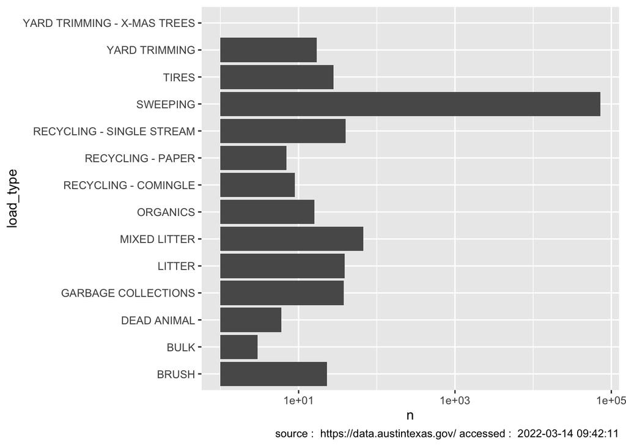

```r
df_waste %>%
  group_by(load_type) %>%
  count(missing = is.na(load_weight)) %>%
  filter(missing) %>%
  mutate(load_type = fct_reorder(load_type, n)) %>%
  ggplot(aes(load_type, n)) +
  geom_col() +
  coord_flip() +
  scale_y_log10() +
  labs(
    caption = paste("source : ", api_waste$citation$source, "accessed : ", api_waste$citation$retrieved)
  )
```

```r
df_waste %>%
  filter(load_type == "SWEEPING") %>%
  count(missing = is.na(load_weight))
```

```
## # A tibble: 2 x 2
##   missing     n
##   <lgl>   <int>
## 1 FALSE   16522
## 2 TRUE    72041
```

Approx 80% sweeping waste load is not recorded.

## Behaviour over time

Checking data collection as a function of time.

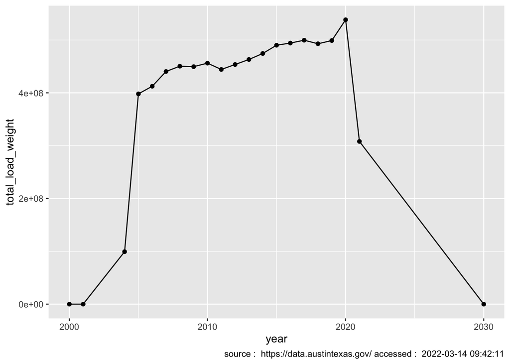

```r
df_waste %>%
  mutate(year = year(load_time)) %>%
  group_by(year) %>%
  summarise(total_load_weight = sum(as.numeric(load_weight), na.rm=T)) %>%
  ggplot(aes(year, total_load_weight)) +
  geom_line() +
  geom_point() +
  labs(
    caption = paste("source : ", api_waste$citation$source, "accessed : ", api_waste$citation$retrieved)
  )
```

- Data seems inconsistently reported prior to 2005.
- Erroneous data present for 2030.
- Is 2021 only partly recorded?

## Waste against Austin GDP

Although checking waste production against population is a good idea, measuring against GDP takes into account the districts productivity and industrial activity as well as population.

GDP data taken from https://fred.stlouisfed.org/series/NGMP12420

```r
df_gdp <- read_csv(here::here("data", "austin-gdp.csv"))
df_waste_gdp <-
  df_waste %>%
  mutate(year = year(load_time)) %>%
  filter(year >= 2005, year <=2020) %>%
  group_by(year) %>%
  summarise(total_load_weight = sum(as.numeric(load_weight), na.rm=T)) %>%
    left_join(df_gdp %>% mutate(year = year(DATE)))
```

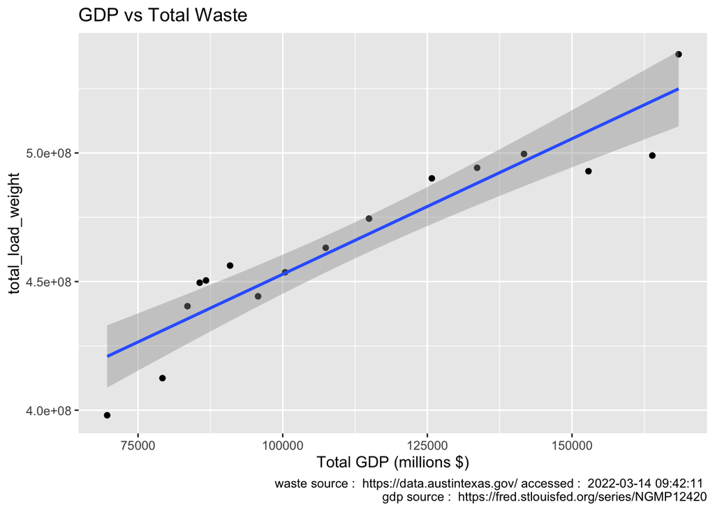

```r
df_waste_gdp %>%
  ggplot(aes(NGMP12420, total_load_weight)) +
  geom_point() +
  labs(
    caption = paste("waste source : ", api_waste$citation$source, "accessed : ", api_waste$citation$retrieved, "\n", "gdp source : ", "https://fred.stlouisfed.org/series/NGMP12420")
  ) + geom_smooth(method = "lm") +
  labs(title = "GDP vs Total Waste", x = "Total GDP (millions $)")
```

```r
l_reg <- lm(total_load_weight ~ NGMP12420, data = df_waste_gdp)
l_reg_time <- lm(total_load_weight ~ year, data = df_waste_gdp)

summary(l_reg)
```

```
##
## Call:
## lm(formula = total_load_weight ~ NGMP12420, data = df_waste_gdp)
##
## Residuals:
##       Min        1Q    Median        3Q       Max
## -22857066  -6970669   3875356  10473435  13399587
##
## Coefficients:
##              Estimate Std. Error t value Pr(>|t|)
## (Intercept) 3.475e+08  1.249e+07  27.819 1.18e-13 ***
## NGMP12420   1.053e+03  1.071e+02   9.833 1.15e-07 ***
## ---
## Signif. codes:  0 '***' 0.001 '**' 0.01 '*' 0.05 '.' 0.1 ' ' 1
##
## Residual standard error: 13100000 on 14 degrees of freedom
## Multiple R-squared:  0.8735, Adjusted R-squared:  0.8645
## F-statistic: 96.69 on 1 and 14 DF,  p-value: 1.15e-07
```

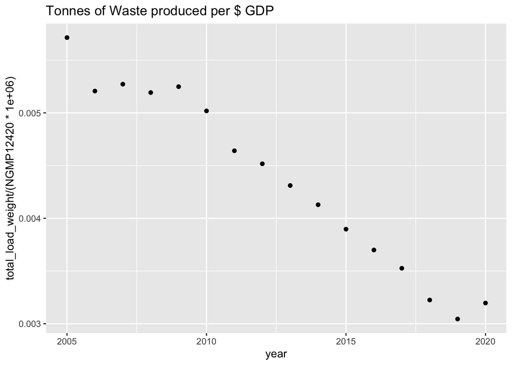

```r
df_waste_gdp %>%
  ggplot(aes(year, total_load_weight/(NGMP12420*1e6))) + geom_point() +
  labs(title="Tonnes of Waste produced per $ GDP")
```

## Garbage Routes

Get route data from API. Not, geometry polygons are nested lists, so we don’t rely on the tabular output from the API, but parse the nested JSON from the raw response.

```r
api_routes <- austin_api("resource/rtqb-u5jq.json")
df_routes <- api_routes$content %>% select(-the_geom) %>% distinct()
```

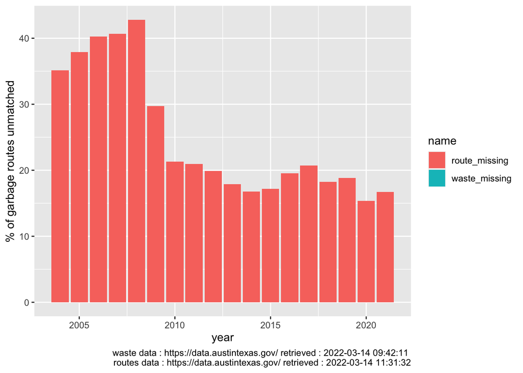

```r
df_waste %>%
  filter(route_type == "GARBAGE COLLECTION") %>%
  select(report_date, route_number) %>%
  full_join(df_routes %>% select(garb_rt), by = c("route_number" = "garb_rt"), keep = TRUE) %>%
  full_join(df_routes %>% select(rt_old), by = c("route_number" = "rt_old"), keep = TRUE) %>%
  mutate(route = coalesce(garb_rt, rt_old)) %>%
  select(report_date, route_number, route) %>%
  group_by(year = year(report_date)) %>%
  summarise(
    waste_missing = 100*sum(is.na(route_number))/n(),
    route_missing = 100*sum(is.na(route))/n()
    ) %>%
  pivot_longer(-year) %>%
  ggplot(aes(year, value, fill = name)) + geom_col() +
  labs(
    x = "year",
    y = "% of garbage routes unmatched",
    caption = paste(
      "waste data :", api_waste$citation$source, "retrieved :", api_waste$citation$retrieved,"\n",
      "routes data :", api_routes$citation$source, "retrieved :", api_routes$citation$retrieved
      )
  )
```

Route data becomes more reliable over time, with ~20% of routes missing from 2010 onwards.

## Plot Routes

Quick hack on how to plot route areas in leaflet.

```r
library(leaflet)
library(sp)

routes_raw <- jsonlite::parse_json(content(api_routes$response, type = "text"))

x <- map(routes_raw, function(x) x$the_geom)

leaflet() %>%
  addTiles() %>%
  addGeoJSON(x)
```